# Analysis Report

```r
library(caret)
```

## Read data and select the predictors.

*I escluded these variables from dataset to obtain model predixtors:*

- X: a counter index;
- user_name: the name of men who performed the exercices;
- cvtd_timestamp: the date and time of exercises;
- new_window and num_window: not understendable variables

```r
data<- read.csv("./pml-training.csv")
predictors<- data[, -c(1,2,5,6,7,160)]
dim(predictors)
```

```
## [1] 19622   154
```

*Then I looked at the characterisitcs of the other variables.*

```r
str(predictors, list.len=dim(predictors)[2])
```

```
## 'data.frame':    19622 obs. of  154 variables:
##  $ raw_timestamp_part_1    : int  1323084231 1323084231 1323084231 1323084232 1323084232 1323084232 1323084232 1323084232 1323084232 1323084232 ...
##  $ raw_timestamp_part_2    : int  788290 808298 820366 120339 196328 304277 368296 440390 484323 484434 ...
##  $ roll_belt               : num  1.41 1.41 1.42 1.48 1.48 1.45 1.42 1.42 1.43 1.45 ...
##  $ pitch_belt              : num  8.07 8.07 8.07 8.05 8.07 8.06 8.09 8.13 8.16 8.17 ...
##  $ yaw_belt                : num  -94.4 -94.4 -94.4 -94.4 -94.4 -94.4 -94.4 -94.4 -94.4 -94.4 ...
##  $ total_accel_belt        : int  3 3 3 3 3 3 3 3 3 3 ...
##  $ kurtosis_roll_belt      : Factor w/ 397 levels "","-0.016850",..: 1 1 1 1 1 1 1 1 1 1 ...
##  $ kurtosis_picth_belt     : Factor w/ 317 levels "","-0.021887",..: 1 1 1 1 1 1 1 1 1 1 ...
##  $ kurtosis_yaw_belt       : Factor w/ 2 levels "","#DIV/0!": 1 1 1 1 1 1 1 1 1 1 ...
##  $ skewness_roll_belt      : Factor w/ 395 levels "","-0.003095",..: 1 1 1 1 1 1 1 1 1 1 ...
##  $ skewness_roll_belt.1    : Factor w/ 338 levels "","-0.005928",..: 1 1 1 1 1 1 1 1 1 1 ...
##  $ skewness_yaw_belt       : Factor w/ 2 levels "","#DIV/0!": 1 1 1 1 1 1 1 1 1 1 ...
##  $ max_roll_belt           : num  NA NA NA NA NA NA NA NA NA NA ...
##  $ max_picth_belt          : int  NA NA NA NA NA NA NA NA NA NA ...
```

[output cut: 140 more lines]

*It appeared that factor variables with 4 or minus levels were not informative. I excluded all these variables.*

*The observations of the other factor variables were mostly NA. There were also numeric variables whit a lot of NA observations.* *I decided to exclude those variables that had a number of NA observations more than 75% of total observations.*

```r
indx<- vector()
for(i in 1:dim(predictors)[2]){
        if(class(predictors[,i]) =="factor") {
                if( length( levels(predictors[,i]) ) <= 4 ) {
                        indx<- c(indx, i)
                }
                else {
                        predictors[,i]<- as.numeric(as.character(predictors[,i]))
                        if(sum(!is.na(predictors[,i])) < dim(predictors)[1]/4) {
                                indx<- c(indx, i)
                        }
                }
        }
        else if(sum(!is.na(predictors[,i])) < dim(predictors)[1]/4) {
                indx<- c(indx, i)
        }
}

predictors<- predictors[,-indx]
dim(predictors)
```

```
## [1] 19622    54
```

## Partitioning and preprocessing data

```r
set.seed(3344)
newData<- predictors
newData$classe<- data$classe
inTrain<- createDataPartition(newData$classe, p=0.75, list=FALSE)
training<- newData[inTrain,]
testing<- newData[-inTrain,]
```

*After partitioning data in training and testing sets, I preprocessed training set using “knnImpute” method for NA values and “pca” method (Principal Component) to reduce the dimensions of problem. I took the first 10 components.*

```r
set.seed(1314)
prComp<- preProcess(training[, -dim(training)[2]], method=c("knnImpute","pca"),
                    pcaComp=10)

prCompTraining<- predict(prComp, newdata=training[, -dim(training)[2]])
prCompTesting<- predict(prComp, newdata=testing[, -dim(testing)[2]])
```

## Select prediction model

*I made a competition between three models.*

### 1)

*First I considered a* **bagging tree** *model with method=“treebag” in train function:*

```r
set.seed(1122)
t1<- Sys.time()
model_bagtree<- train(training$classe ~., data=prCompTraining, method="treebag")
int<- difftime(Sys.time(), t1, units="secs")
predict_bagtree<- predict(model_bagtree, newdata=prCompTesting)
M<-confusionMatrix(predict_bagtree, testing$classe)
M
```

```
## Confusion Matrix and Statistics
##
##           Reference
## Prediction    A    B    C    D    E
##          A 1336   24   21   14    7
##          B   17  879   10   16   25
##          C   21   21  805   34   12
##          D   13   14   16  729    9
##          E    8   11    3   11  848
##
## Overall Statistics
##
##                Accuracy : 0.937
##                  95% CI : (0.93, 0.944)
##     No Information Rate : 0.284
##     P-Value [Acc > NIR] : <2e-16
##
##                   Kappa : 0.921
##  Mcnemar's Test P-Value : 0.0113
##
## Statistics by Class:
##
##                      Class: A Class: B Class: C Class: D Class: E
## Sensitivity             0.958    0.926    0.942    0.907    0.941
## Specificity             0.981    0.983    0.978    0.987    0.992
## Pos Pred Value          0.953    0.928    0.901    0.933    0.963
## Neg Pred Value          0.983    0.982    0.988    0.982    0.987
## Prevalence              0.284    0.194    0.174    0.164    0.184
## Detection Rate          0.272    0.179    0.164    0.149    0.173
## Detection Prevalence    0.286    0.193    0.182    0.159    0.180
## Balanced Accuracy       0.969    0.955    0.960    0.947    0.966
```

*the time of execution were 949.1 seconds and the accuracy 0.9374.*

### 2)

*Then I took a* **random forest** *model: I tried for trees number equal to 20, 50, 100 and 150, and I signed accuracy:*

**Trees number** | **Accuracy** | **System Time**

**20** | **0.9488** | **84.26 secs**

**50** | **0.9507** | **206.96 secs**

**100** | **0.9535** | **387.70 secs**

**150** | **0.9578** | **574.58 secs**

*then I decided to use ntree=50 value in train function.*

```r
set.seed(2323)
t1<- Sys.time()
model_rf<- train(training$classe ~., data=prCompTraining, method="rf", ntree=50)
int<- difftime(Sys.time(), t1, units="secs")
predict_rf<- predict(model_rf, newdata=prCompTesting)
M<- confusionMatrix(predict_rf, testing$classe)
M
```

```
## Confusion Matrix and Statistics
##
##           Reference
## Prediction    A    B    C    D    E
##          A 1352   22   11    9    3
##          B    9  878    7    8    9
##          C   22   31  820   38   15
##          D    8   10   16  745    7
##          E    4    8    1    4  867
##
## Overall Statistics
##
##                Accuracy : 0.951
##                  95% CI : (0.944, 0.957)
##     No Information Rate : 0.284
##     P-Value [Acc > NIR] : < 2e-16
##
##                   Kappa : 0.938
##  Mcnemar's Test P-Value : 1.03e-06
##
## Statistics by Class:
##
##                      Class: A Class: B Class: C Class: D Class: E
## Sensitivity             0.969    0.925    0.959    0.927    0.962
## Specificity             0.987    0.992    0.974    0.990    0.996
## Pos Pred Value          0.968    0.964    0.886    0.948    0.981
## Neg Pred Value          0.988    0.982    0.991    0.986    0.992
## Prevalence              0.284    0.194    0.174    0.164    0.184
## Detection Rate          0.276    0.179    0.167    0.152    0.177
## Detection Prevalence    0.285    0.186    0.189    0.160    0.180
## Balanced Accuracy       0.978    0.958    0.966    0.958    0.979
```

*the time of execution were 211.6 seconds and the accuracy 0.9507.*

*The following plot display the percentage rate error over the number of tree:*

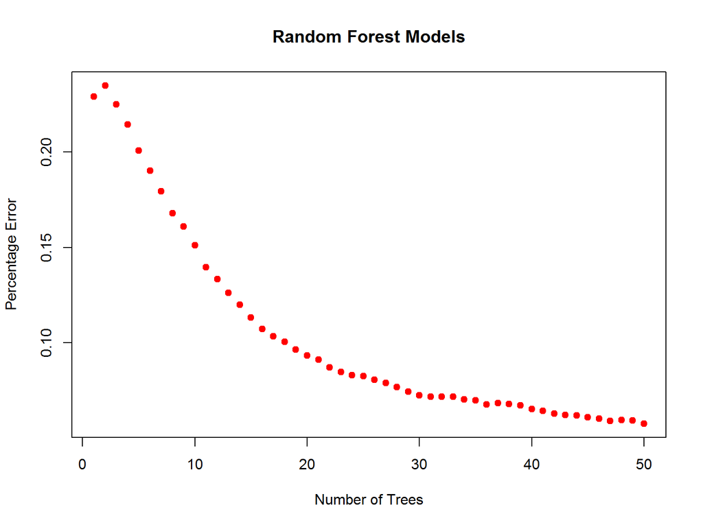

```r
plot(model_rf$finalModel$err.rate[,1], main="Random Forest Models",
     xlab="Number of Trees", ylab="Percentage Error", pch=19, cex=1, col="red")
```

### 3)

*Finally I took a* **boosting tree** *model, using method=“gbm” in train function. This algorithm take a lot of time and pc memory.*

```r
set.seed(3344)
t1<- Sys.time()
model_boostree<- train(training$classe ~., data=prCompTraining, method="gbm",
                       verbose=FALSE)
int<- difftime(Sys.time(), t1, units="secs")
predict_boostree<- predict(model_boostree, newdata=prCompTesting)
M<-confusionMatrix(predict_boostree, testing$classe)
M
```

```
## Confusion Matrix and Statistics
##
##           Reference
## Prediction    A    B    C    D    E
##          A 1148   96  118   65   55
##          B   55  636   49   59   86
##          C   78  102  636   80   91
##          D   89   62   24  580   38
##          E   25   53   28   20  631
##
## Overall Statistics
##
##                Accuracy : 0.74
##                  95% CI : (0.728, 0.753)
##     No Information Rate : 0.284
##     P-Value [Acc > NIR] : <2e-16
##
##                   Kappa : 0.671
##  Mcnemar's Test P-Value : <2e-16
##
## Statistics by Class:
##
##                      Class: A Class: B Class: C Class: D Class: E
## Sensitivity             0.823    0.670    0.744    0.721    0.700
## Specificity             0.905    0.937    0.913    0.948    0.969
## Pos Pred Value          0.775    0.719    0.644    0.731    0.834
## Neg Pred Value          0.928    0.922    0.944    0.946    0.935
## Prevalence              0.284    0.194    0.174    0.164    0.184
## Detection Rate          0.234    0.130    0.130    0.118    0.129
## Detection Prevalence    0.302    0.180    0.201    0.162    0.154
## Balanced Accuracy       0.864    0.804    0.829    0.835    0.834
```

*the time of execution were 1041.71 seconds and the accuracy 0.7404.*

**A the end, the best model was the random forest model (lower system time and higher accuracy), and I used it as prediction alghoritm for “class” variable of the 20 observation of pml-testing.csv file**

## Predictions

*First of all I made over new dataset in pml-testing.csv file, just applying the same transformations applied to data in pml-training.csv file:*

```r
newObsData<- read.csv("./pml-testing.csv")
newObsPredictors<- newObsData[, -c(1,2,5,6,7,160)]
newObsPredictors<- newObsPredictors[, -indx]
dim(newObsPredictors)
```

```
## [1] 20 54
```

*I checked the predictors were the same for old and new dataset.*

```r
k<- 0
for(j in 1:dim(predictors)[2]) {
        if(names(predictors)[j]==names(newObsPredictors)[j]) {
                k<- k + 1.
        }
}
if(k == dim(predictors)[2]) print("Predictors are the same")
```

```
## [1] "Predictors are the same"
```

*And I calculated the same principal component applied before to data in pml-training.csv file.*

```r
prCompNewObsPredictors<- predict(prComp, newdata=newObsPredictors)
```

*Then I could make predictions:*

```r
newPredictions<- predict(model_rf, newdata=prCompNewObsPredictors)
newPredictions
```

```
##  [1] B A B A A E D B A A A C B A E E A B B B
## Levels: A B C D E
```